# Predicting Client Subscription for Bank’s Term Deposit

### Decision Tree (CART)

CART (Classification & Regression Trees) is a Decision Tree Algorithm used for classification or regression predictive modeling analysis. (Brownlee, 2016)

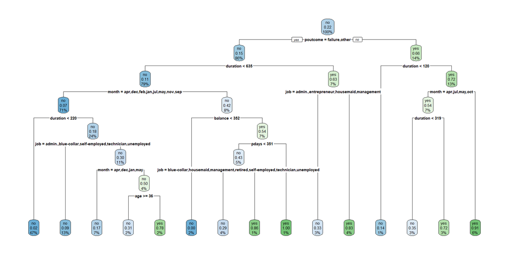

```r
# Decision Tree - CART
set.seed(123)
library(rpart)
library(rpart.plot)
tree1 <- rpart(y~., data = train, method = 'class')
rpart.plot(tree1, extra = "auto")
```

From the top, the overall probability of subscribing to a term deposit is 22%. The node asks whether the outcome of the previous marketing campaign was a failure.

If yes, then we would move leftwards to the second node where 86% had a failed outcome of the previous marketing campaign with 15% of subscribing probability. Then in that second node, we check if the last called duration was less than 635 seconds.

If it were more than 635, we would move rightwards to the third node, where 7% had a call for more than 635 seconds with a 63% probability of subscribing.

We will then keep going on with the pattern to understand further and analyse which variable impacts the likelihood of subscribing to a term deposit.

```r
pred_new <- predict(tree1, test, type="class")
table_1 <- table(test$y,pred_new)
table_1
```

```
##      pred_new
##        no yes
##   no  155  23
##   yes  25  26
```

```r
accuracytest <- sum(diag(table_1))/sum(table_1)
print(paste('Test Accuracy', accuracytest))
```

```
## [1] "Test Accuracy 0.790393013100437"
```

The model correctly predicted 155 non-subscribers and 26 subscribers. Also, the model misclassified 25 subscribers as non-subscribers and 23 non-subscribers as people who subscribed.

However, the test accuracy is still relatively high, at around 79%.

```r
accuracytuned <- function(tree1) {
  pred_new <- predict(tree1, test, type = 'class')
  table_1 <- table(test$y, pred_new)
  accuracytest <- sum(diag(table_1)) / sum(table_1)
  accuracytest
}

control <- rpart.control(minsplit = 4,
                         minbucket = round(4/ 3),
                         maxdepth = 9,
                         cp = 0)
tuned_mod <- rpart(y~., data = train, method = 'class', control = control)
accuracytuned(tuned_mod)
```

```
## [1] 0.7991266
```

```r
# Tuned parameters can lead to higher accuracy
```

It can also be further accurately tuned with adjustments to its parameters to get higher performance.

### Random Forest

```r
# Random Forest
library(randomForest)
set.seed(123)

# making the models with 100 trees
subscribed_rf <- randomForest(y~., data=train, importance=T, ntree=100)

importance(subscribed_rf)
```

```
##                   no        yes MeanDecreaseAccuracy MeanDecreaseGini
## age        1.6143450 -0.4551771            1.2397005       13.3604446
## job        0.7143156 -0.3070630            0.5237337       15.2407836
## marital    2.3532654 -0.4536149            1.8026621        4.6464370
## education  3.5568035 -1.8061264            2.0763904        3.7386563
## default    0.9790454 -1.0050378            0.4053407        0.3960559
## balance    0.7375421  0.4979873            1.0017616       14.2649913
## housing    2.3924199  2.1850122            3.1050201        2.8156016
## loan      -1.5801904  0.7407660           -0.5585783        0.8646363
## contact   -1.1543406  0.3268998           -0.6457181        0.6403557
## day        2.9265880 -0.4016363            2.5490644       12.0936509
## month      6.4772399  4.5769447            7.6933475       24.1711343
## duration   8.2638476 14.4117347           14.8151026       42.2763029
## campaign  -1.7458787 -0.1415128           -1.2743314        3.9368369
## pdays      5.6235433  6.1413998            7.2116391       18.9983892
## previous   0.1319018  1.0675435            0.7706671        7.8994696
## poutcome   9.4229030 13.5160211           14.8236041       21.6955763
```

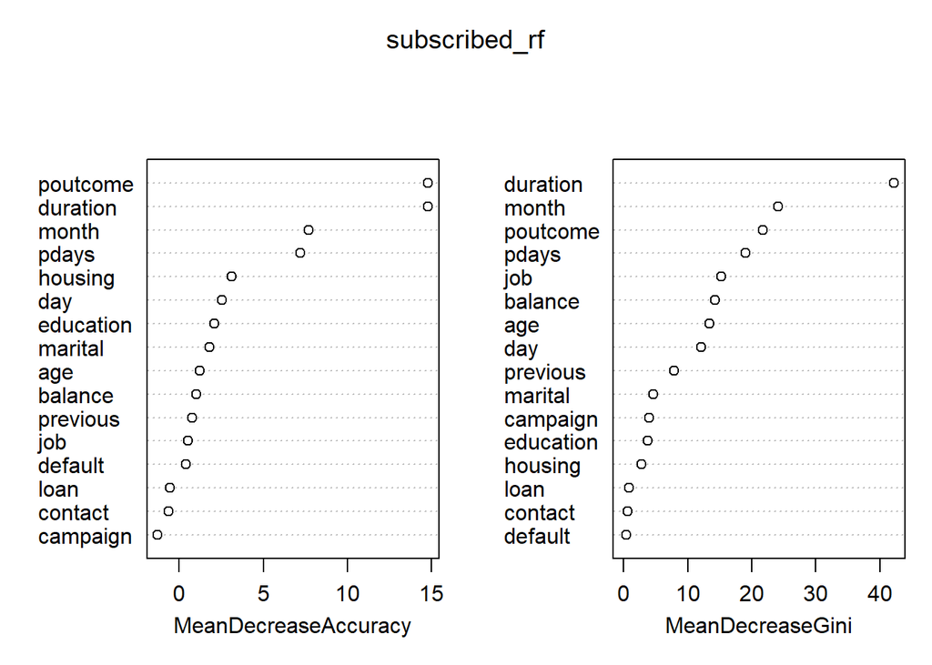

```r
varImpPlot(subscribed_rf)
```

```r
# Duration and month are important predictors on whether customers subscribe.
```

Running the equation above, the Random Forest model would show the significance of each predictor in the data affecting the subscription choice. The last contact duration is the most important predictor, followed by the last contact month of the year and the previous marketing campaign’s outcome.

```r
newtest <- predict(subscribed_rf,test)
error <- mean(newtest != test$y)
print(paste('Accuracy',1-error))
```

```
## [1] "Accuracy 0.842794759825327"
```

```r
# The model is almost 84% accurate.
```

The accuracy of the Random Forest method would be as high as about 84%.

### Conclusion

Comparing all the models, we can see that Logistic Regression has an accuracy of 84%, Decision Tree via CART with 79%, Random Forest Method with 84%.

Therefore, Logistic Regression and Random Forest would both be the ideal predictive model for classification.

Both ideal models have indicated the same few variables that are significant and will impact the prediction of subscription for a term deposit: the last contact duration, outcome of the previous marketing campaign and the last contact month of the year.

[[LinkedIn](https://www.linkedin.com/in/evantyy)] [[GitHub](https://github.com/evantyy/client-subscription-predict)]

© Copyright. Evangeline Tan 2021.